# One hot encoding with `recipes` package

Since once of the best way to learn, is to explain, I want to share with you this quick introduction to `recipes` package, from the `tidymodels` family. It can help us to automatize some data preparation tasks.

The overview is:

- How to create a `recipe`
- How to add a `step`
- How to do the `prep`
- Getting the data with `juice`!
- Apply the prep to new data
- What is the difference between `bake` and `juice`?
- Dealing with new values in recipes (`step_novel`)

Since I’m new to this package, if you have something to add just put in the comments ;)

## Introduction

If you are new to R or you do a 1-time analysis, you could not see the main advantage of this, which is -in my opinion- to have most of the **data preparation** steps in one place. This way is easier to split between dev and prod.

- Dev: The stage in which we create the model
- Prod: The moment in which we run the model with new data

The other big advantage is it follows the *tidy* philosophy, so many things will be familiar.

## How to use `recipes` for one hot encoding

It is focused on **one hot encoding**, but many other functions like scaling, applying PCA and others can be performed.

But first, **what is one hot encoding?**

It’s a data preparation technique to convert all the categorical variables into numerical, by assigning a value of `1` when the row belongs to the category. If the variable has 100 unique values, the final result will contain 100 columns.

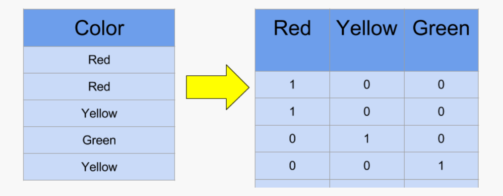

That’s why it is a* **good practice to reduce the cardinality** of the variable before continuing Learn more about it in the [High Cardinality Variable in Predictive Modeling](https://livebook.datascienceheroes.com/data-preparation.html#high_cardinality_predictive_modeling) from the *Data Science Live Book* 📗.

Let’s start the example with recipes!

### 1st - How to create a `recipe`

```r
library(recipes)
library(tidyverse)

set.seed(3.1415)
iris_tr=sample_frac(iris, size = 0.7)

rec = recipe( ~ ., data = iris_tr)

rec
```

```
## Data Recipe
##
## Inputs:
##
##       role #variables
##  predictor          5
```

```r
summary(rec)
```

```
## # A tibble: 5 x 4
##   variable     type    role      source
##   <chr>        <chr>   <chr>     <chr>
## 1 Sepal.Length numeric predictor original
## 2 Sepal.Width  numeric predictor original
## 3 Petal.Length numeric predictor original
## 4 Petal.Width  numeric predictor original
## 5 Species      nominal predictor original
```

The formula `~ .`, specifies that all the variables are predictors (with no outcomes).

Please note now we have two different data types, numeric and nominal (not factor nor character).

### 2nd - How to add a step

Now we add the step to create the dummy variables, or the **one hot encoding**, which can be seen as the same.

When we do the one hot encoding (`one_hot = T`), all the levels will be present in the final result. Conversely, when we create the dummy variables, we could have all of the variables, or one less (to avoid the multi-correlation issue).

```r
rec_2 = rec %>% step_dummy(Species, one_hot = T)

rec_2
```

```
## Data Recipe
##
## Inputs:
##
##       role #variables
##  predictor          5
##
## Operations:
##
## Dummy variables from Species
```

Now we see the dummy step.

### 3rd - How to do the `prep`

`prep` is like putting all the ingredients together, *but we didn’t cook yet!*

It generates the metadata to do the data preparation.

As we can see here:

```r
# Aplico la receta, que tiene 1 step, a los datos
d_prep=rec_2 %>% prep(training = iris_tr, retain = T)

d_prep
```

```
## Data Recipe
##
## Inputs:
##
##       role #variables
##  predictor          5
##
## Training data contained 105 data points and no missing data.
##
## Operations:
##
## Dummy variables from Species [trained]
```

Note we are in the “training” or *dev* stage. That’s why we see the parameter `training`.

We will see `retain = T` in the next step.

Checking:

```r
summary(d_prep)
```

```
## # A tibble: 7 x 4
##   variable           type    role      source
##   <chr>              <chr>   <chr>     <chr>
## 1 Sepal.Length       numeric predictor original
## 2 Sepal.Width        numeric predictor original
## 3 Petal.Length       numeric predictor original
## 4 Petal.Width        numeric predictor original
## 5 Species_setosa     numeric predictor derived
## 6 Species_versicolor numeric predictor derived
## 7 Species_virginica  numeric predictor derived
```

**Whoila!** 🎉 We have the 3-new `derived` columns (one hot), and it removed the original `Species`.

### 4th - Getting the data with `juice`!

Using `juice` function:

```r
d2=juice(d_prep)

head(d2)
```

```
## # A tibble: 6 x 7
##   Sepal.Length Sepal.Width Petal.Length Petal.Width Species_setosa
##          <dbl>       <dbl>        <dbl>       <dbl>          <dbl>
## 1          5           3            1.6         0.2              1
## 2          6.9         3.2          5.7         2.3              0
## 3          6.3         3.3          4.7         1.6              0
## 4          5.3         3.7          1.5         0.2              1
## 5          6.3         2.3          4.4         1.3              0
## 6          6.7         3            5.2         2.3              0
## # … with 2 more variables: Species_versicolor <dbl>,
## #   Species_virginica <dbl>
```

`juice` worked because we *retained* the training data in the 3rd step (`retain = T`). Otherwise it would have returned:

⚠️ *Error: Use `retain = TRUE` in `prep` to be able to extract the training set`*

### 5th - Apply the prep to new data

Now imagine we have **new data** as follows:

```r
iris_new=sample_n(iris, size = 5) # taking 5 random rows

d_baked=bake(d_prep, newdata = iris_new)

d_baked
```

```
## # A tibble: 5 x 7
##   Sepal.Length Sepal.Width Petal.Length Petal.Width Species_setosa
##          <dbl>       <dbl>        <dbl>       <dbl>          <dbl>
## 1          6.4         3.2          4.5         1.5              0
## 2          4.6         3.4          1.4         0.3              1
## 3          5.2         2.7          3.9         1.4              0
## 4          4.8         3.4          1.6         0.2              1
## 5          4.8         3            1.4         0.3              1
## # … with 2 more variables: Species_versicolor <dbl>,
## #   Species_virginica <dbl>
```

It worked!

`bake` receives the `prep` object (`d_prep`) and it applies to the `newdata` (`iris_new`)

### What is the difference between `bake` and `juice`?

From this perspective given the training data, following data frames are the same:

```r
d_tr_1=bake(d_prep, newdata = iris_tr)
d_tr_2=d2=juice(d_prep) # with retain=T

identical(d_tr_1, d_tr_2)
```

```
## [1] TRUE
```

## Dealing with new values in recipes

Simulate a new value:

```r
new_row=iris[1,] %>% mutate(Species=as.character(Species))
new_row[1, "Species"]="i will break your code"

new_row
```

```
##   Sepal.Length Sepal.Width Petal.Length Petal.Width                Species
## 1          5.1         3.5          1.4         0.2 i will break your code
```

We use `bake` to convert the new data set:

```r
d2_b=bake(d_prep, newdata = new_row)
```

[output not shown]

### The solution! Use `step_novel`

(Thanks to Max Kuhn)

When we do the `prep`, we have to add `step_novel`. So any new value will be assigned to the `_new` category.

We will start right from the beginning:

```r
rec_2_bis = recipe( ~ ., data = iris_tr) %>%
  step_novel(Species) %>%
  step_dummy(Species, one_hot = T)

prep_bis = prep(rec_2_bis, training = iris_tr)
```

Get to final data, and check it:

```r
processed = bake(prep_bis, iris_tr)

funModeling::df_status(processed)
```

```
##             variable q_zeros p_zeros q_na p_na q_inf p_inf    type unique
## 1       Sepal.Length       0    0.00    0    0     0     0 numeric     32
## 2        Sepal.Width       0    0.00    0    0     0     0 numeric     23
## 3       Petal.Length       0    0.00    0    0     0     0 numeric     42
## 4        Petal.Width       0    0.00    0    0     0     0 numeric     20
## 5     Species_setosa      68   64.76    0    0     0     0 numeric      2
## 6 Species_versicolor      69   65.71    0    0     0     0 numeric      2
## 7  Species_virginica      73   69.52    0    0     0     0 numeric      2
## 8        Species_new     105  100.00    0    0     0     0 numeric      1
```

Please note that `Species_new` **has been automatically created** (with zeros).

👉 This ensures it **runs well once** in production.

Now let’s see what happen when we have the new value:

```r
new_row_2=bake(prep_bis, newdata = new_row)

new_row_2 %>% select(Species_new)
```

```
## # A tibble: 1 x 1
##   Species_new
##         <dbl>
## 1           1
```

It works!

## Conclusions 💡

The `recipes` package seems to be a good way to standardize certain data preparation tasks. Probably one of the strongest points in R, alongside the `dplyr` package.

📌 Take care of the **data pipeline**, it is what interviewers will ask you for.

I tried to cover with simple and reproducible examples, many of the situations that happen when we work with productive environments, in the [Data Science Live Book](https://livebook.datascienceheroes.com) 📗 (open-source).

Have fun 🚀

📬 You can found me at: [Linkedin](https://www.linkedin.com/in/pcasas/) & [Twitter](https://twitter.com/pabloc_ds).

### References:

- [Basic recipes example](https://tidymodels.github.io/recipes/articles/Simple_Example.html)
- [Modeling with parsnip and tidymodels](https://www.benjaminsorensen.me/post/modeling-with-parsnip-and-tidymodels/) by Benjamin Sorensen.
- [Creating and Preprocessing a Design Matrix with Recipes](https://www.rstudio.com/resources/webinars/creating-and-preprocessing-a-design-matrix-with-recipes/) (video)

### Other posts you might like 🤓…

- 🔍 [Model interpretability with SHAP](https://blog.datascienceheroes.com/how-to-interpret-shap-values-in-r/)
- 📊 [Supervized binning](https://blog.datascienceheroes.com/discretization-recursive-gain-ratio-maximization/)